# GRADO DE DIFICULTAD DE LOS CURSOS GENERALES Y SU RELACIÓN CON LA CANTIDAD DE INGRESANTES (2022-I y 2022-II) DESAPROBADOS Y/O RETIRADOS EN UTEC

## OBJETIVO 1

### Comprobar si la nivelación ayudó a afrontar el primer ciclo.

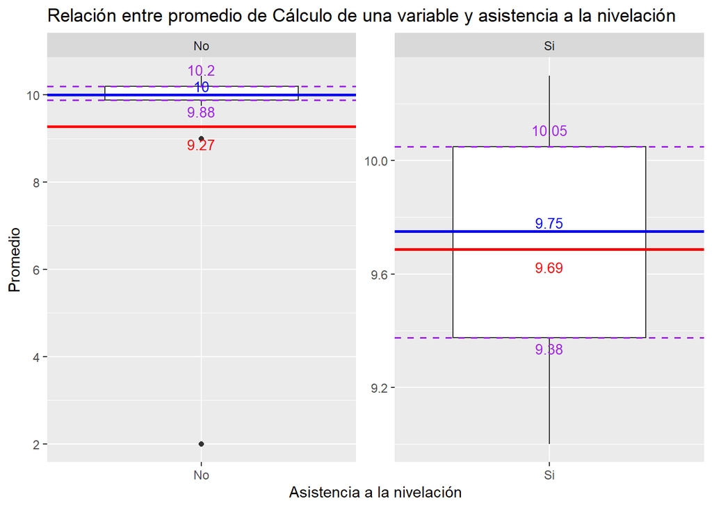

```r
library(ggplot2)
data <- data.frame(promedio = DF$promedio_calculo[DF$promedio_calculo != 0],
                   asistencia = factor(DF$Nivelacion[DF$promedio_calculo != 0]))

data <- na.omit(data)
#data <- data[!data %in% "no participo"]
mean_vals <- data %>%
  group_by(asistencia) %>%
  summarise(mean_val = mean(promedio),
            median_val = median(promedio),
            q1_val = quantile(promedio, 0.25),
            q3_val = quantile(promedio, 0.75))

ggplot(data, aes(x = asistencia, y = promedio)) +
  geom_boxplot() +
  geom_hline(data = mean_vals, aes(yintercept = mean_val), color = "red", linetype = "solid", size = 1) +
  geom_hline(data = mean_vals, aes(yintercept = median_val), color = "blue", linetype = "solid", size = 1) +
  geom_hline(data = mean_vals, aes(yintercept = q1_val), color = "purple", linetype = "dashed", size = 0.6) +
  geom_hline(data = mean_vals, aes(yintercept = q3_val), color = "purple", linetype = "dashed", size = 0.6) +
  geom_text(data = mean_vals, aes(x = asistencia, y = mean_val, label = round(mean_val, 2)), vjust = 2.1, color = "red", size = 3.5) +
  geom_text(data = mean_vals, aes(x = asistencia, y = median_val, label = round(median_val, 2)), vjust = -0.3, color = "blue", size = 3.5) +
  geom_text(data = mean_vals, aes(x = asistencia, y = q1_val, label = round(q1_val, 2)), vjust = 1.5, color = "purple", size = 3.5) +
  geom_text(data = mean_vals, aes(x = asistencia, y = q3_val, label = round(q3_val, 2)), vjust = -1, color = "purple", size = 3.5) +
  xlab("Asistencia a la nivelación") +
  ylab("Promedio") +
  ggtitle("Relación entre promedio de Cálculo de una variable y asistencia a la nivelación") +
  facet_wrap(~asistencia, ncol = 2, scales = "free")  # Agregar facetas para separar los boxplots por asistencia
```

**Estudiantes desaprobados que NO fueron a nivelación (Bloxpot1)**

Media -> 9.27 Mediana -> 10 Rango intercuartil -> 10.2 - 9.88 = 0.32

**Estudiantes desaprobados que SI fueron a nivelación (Bloxpot2)**

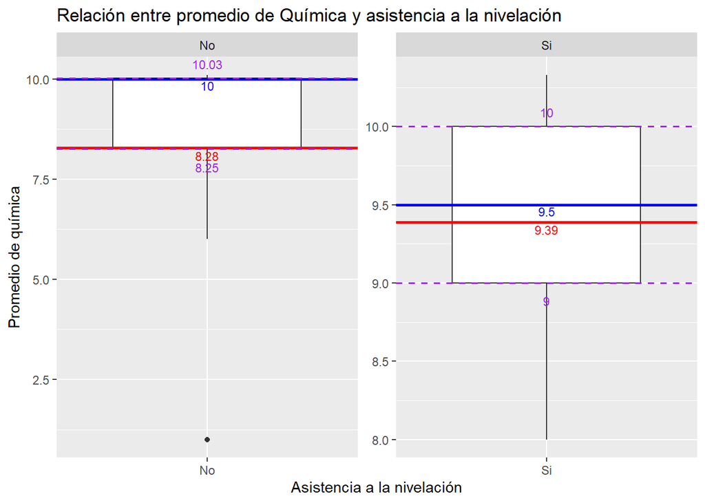

```r
data <- data.frame(promedio = DF$promedio_quimica[DF$promedio_quimica != 0],
                   asistencia = factor(DF$Nivelacion[DF$promedio_quimica != 0]))

data <- na.omit(data)
mean_vals <- data %>%
  group_by(asistencia) %>%
  summarise(mean_val = mean(promedio),
            median_val = median(promedio),
            q1_val = quantile(promedio, 0.25),
            q3_val = quantile(promedio, 0.75))

ggplot(data, aes(x = asistencia, y = promedio)) +
  geom_boxplot() +
  geom_hline(data = mean_vals, aes(yintercept = mean_val), color = "red", linetype = "solid", size = 1) +
  geom_hline(data = mean_vals, aes(yintercept = median_val), color = "blue", linetype = "solid", size = 1) +
  geom_hline(data = mean_vals, aes(yintercept = q1_val), color = "purple", linetype = "dashed", size = 0.6) +
  geom_hline(data = mean_vals, aes(yintercept = q3_val), color = "purple", linetype = "dashed", size = 0.6) +
  geom_text(data = mean_vals, aes(x = asistencia, y = mean_val, label = round(mean_val, 2)), vjust = 1.3, color = "red", size = 3) +
  geom_text(data = mean_vals, aes(x = asistencia, y = median_val, label = round(median_val, 2)), vjust = 1.2, color = "blue", size = 3) +
  geom_text(data = mean_vals, aes(x = asistencia, y = q1_val, label = round(q1_val, 2)), vjust = 2.4, color = "purple", size = 3) +
  geom_text(data = mean_vals, aes(x = asistencia, y = q3_val, label = round(q3_val, 2)), vjust = -1, color = "purple", size = 3) +
  xlab("Asistencia a la nivelación") +
  ylab("Promedio de química") +
  ggtitle("Relación entre promedio de Química y asistencia a la nivelación") +
  facet_wrap(~asistencia, ncol = 2, scales = "free")  # Agregar facetas para separar los boxplots por asistencia
```

**Estudiantes desaprobados que NO fueron a nivelación (Bloxpot1)**

**Estudiantes desaprobados que SI fueron a nivelación (Bloxpot2)**

Media -> 9.39 Mediana -> 9.5 Rango intercuartil -> 10 - 9 = 1

Los estudiantes que no fueron a la nivelación no solamente tienen una mayor dispersión, sino que también tiene datos atípicos. Por lo tanto, se aprecia nuevamente que los estudiantes que Sí fueron a la nivelación tienen un mejor promedio, ya que el 50% de los que pertenecen a este grupo tienen promedio entre 9 y 10, mientras que el resto tiene un promedio entre 8.25 y 10.03.

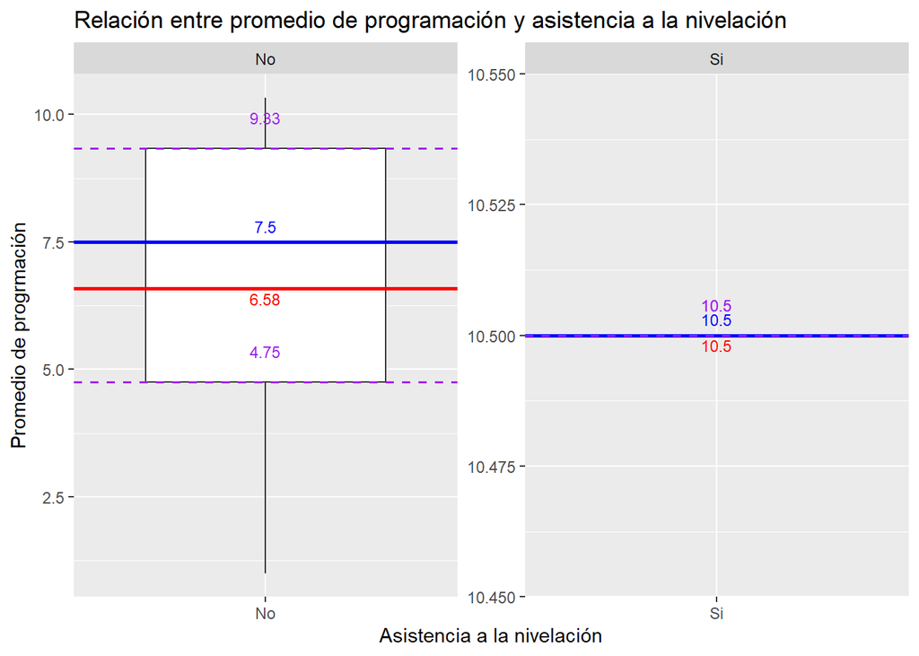

```r
data <- data.frame(promedio = DF$promedio_progra[DF$promedio_progra != 0],
                   asistencia = factor(DF$Nivelacion[DF$promedio_progra != 0]))

data <- na.omit(data)
mean_vals <- data %>%
  group_by(asistencia) %>%
  summarise(mean_val = mean(promedio),
            median_val = median(promedio),
            q1_val = quantile(promedio, 0.25),
            q3_val = quantile(promedio, 0.75),
            interquartile_range = q3_val - q1_val)  # Calcular el rango intercuartil

ggplot(data, aes(x = asistencia, y = promedio)) +
  geom_boxplot() +
  geom_hline(data = mean_vals, aes(yintercept = mean_val), color = "red", linetype = "solid", size = 1) +
  geom_hline(data = mean_vals, aes(yintercept = median_val), color = "blue", linetype = "solid", size = 1) +
  geom_hline(data = mean_vals, aes(yintercept = q1_val), color = "purple", linetype = "dashed", size = 0.6) +
  geom_hline(data = mean_vals, aes(yintercept = q3_val), color = "purple", linetype = "dashed", size = 0.6) +
  geom_text(data = mean_vals, aes(x = asistencia, y = mean_val, label = round(mean_val, 2)), vjust = 1.3, color = "red", size = 3) +
  geom_text(data = mean_vals, aes(x = asistencia, y = median_val, label = round(median_val, 2)), vjust = -0.8, color = "blue", size = 3) +
  geom_text(data = mean_vals, aes(x = asistencia, y = q1_val, label = round(q1_val, 2)), vjust = -2, color = "purple", size = 3) +
  geom_text(data = mean_vals, aes(x = asistencia, y = q3_val, label = round(q3_val, 2)), vjust = -2, color = "purple", size = 3) +

  xlab("Asistencia a la nivelación") +
  ylab("Promedio de progrmación") +
  ggtitle("Relación entre promedio de programación y asistencia a la nivelación") +
  facet_wrap(~asistencia, ncol = 2, scales = "free")  # Agregar facetas para separar los boxplots por asistencia
```

**Estudiantes desaprobados que NO fueron la nivelación (Bloxpot1)**

**Estudiantes desaprobados que SI fueron la nivelación (Bloxpot2)**

Media -> 10.5 Mediana -> 10.5

Concluimos que la nivelación es útil para poder sacar un mejor promedio en los cursos de “cálculo de una variable” y “química”.

## OBJETIVO 2

### Identificar los cursos que tienen mayor o menor impacto en la tasa de abandono estudiantil.

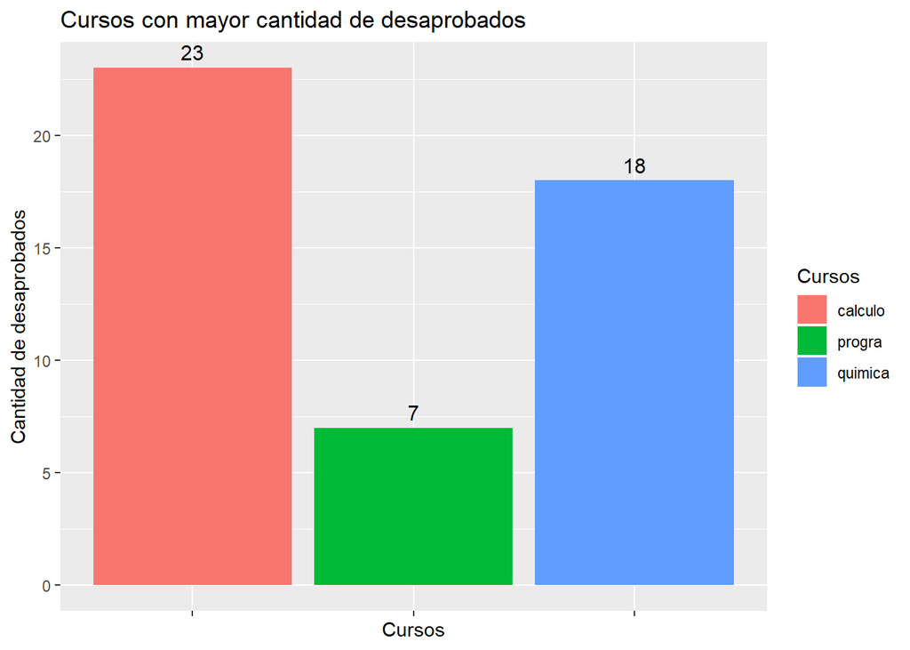

```r
# Filtrar las observaciones donde las variables "calculo", "quimica" y "progra" son TRUE
filtered_calculo <- DF[DF$calculo, ]
filtered_quimica <- DF[DF$quimica, ]
filtered_progra <- DF[DF$progra, ]


# Calcular la cantidad de desaprobados para cada curso
desaprobados_calculo <- sum(filtered_calculo$Veces_desaprobado)
desaprobados_quimica <- sum(filtered_quimica$Veces_desaprobado)
desaprobados_progra <- sum(filtered_progra$Veces_desaprobado)

# Crear un data frame con las variables de interés
data <- data.frame(Cursos = c("calculo", "quimica", "progra"),
                   Veces_desaprobado = c(desaprobados_calculo, desaprobados_quimica, desaprobados_progra))

# Generar el gráfico de barras
library(ggplot2)
ggplot(data, aes(x = Cursos, y = Veces_desaprobado, fill = Cursos)) +
  geom_bar(stat = "identity") +
  geom_text(aes(label = Veces_desaprobado), vjust = -0.5, color = "black", size = 4) +
  xlab("Cursos") +
  ylab("Cantidad de desaprobados") +
  ggtitle("Cursos con mayor cantidad de desaprobados") +
  scale_x_discrete(labels = NULL)
```

Agrupamos la cantidad de estudiantes que desaprobaron en un solo grupo. No consideramos Lab. de Química porque no tiene mentoría, ni nivelación.

Podemos afirmar que Cálculo de una Variable tiene mayor impacto en la tasa de abandono estudiantil, ¿Se debería quitar el curso de Cálculo para disminuir la tasa de abandono?

La respuesta es no, antes de que inicie el ciclo el estudiante tiene la oportunidad de ingresar a una nivelación. Además, durante el inicio de su ciclo tiene la oportunidad de ingresar a las mentorías académicas.

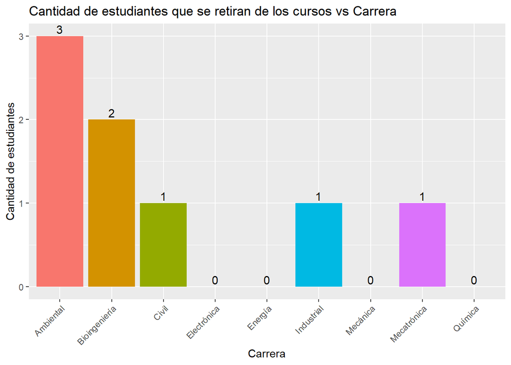

```r
filtered_data <- DF[!(DF$Veces_retirado == "NA" | DF$Carrera == "NA"), ]

data <- data.frame(repiticiones = filtered_data$Veces_retirado, carrera = filtered_data$Carrera)
sum_repeticiones <- aggregate(repiticiones ~ carrera, data, sum)


library(ggplot2)
ggplot(sum_repeticiones, aes(x = carrera, y = repiticiones, fill = carrera)) +
  geom_bar(stat = "identity") +
  geom_text(aes(label = repiticiones), vjust = -0.3, color = "black", size = 4) +
  xlab("Carrera") +
  ylab("Cantidad de estudiantes") +
  ggtitle("Cantidad de estudiantes que se retiran de los cursos vs Carrera") +
  theme(axis.text.x = element_text(angle = 45, hjust = 1),
        legend.position = "none")
```

```r
data <- data.frame(repiticiones = filtered_data$Veces_retirado, carrera = filtered_data$Carrera)
sum_repeticiones <- aggregate(repiticiones ~ carrera, data, sum)
```

Esta información nos ayuda a responder a nuestro segundo objetivo, ya que podemos plantear futuras soluciones en campos específicos ante el problema del abandono estudiantil.

## OBEJTIVO 3

### Confirmar la necesidad de más mentores y asesorías en los cursos que requieran.

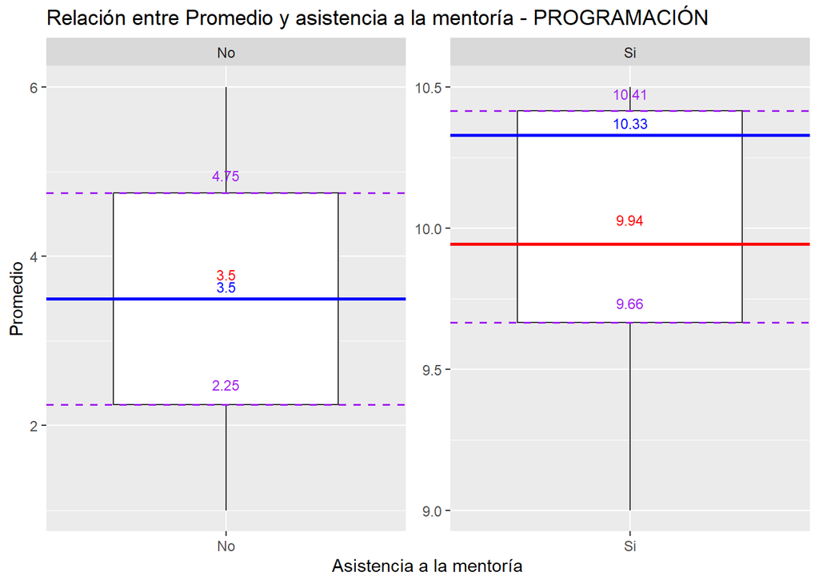

```r
data <- data.frame(promedio = DF$promedio_progra[DF$promedio_progra != 0],
                   asistencia = factor(DF$mentoria[DF$promedio_progra != 0]))

data <- na.omit(data)
#data <- data[!data %in% "no participo"]
mean_vals <- data %>%
  group_by(asistencia) %>%
  summarise(mean_val = mean(promedio),
            median_val = median(promedio),
            q1_val = quantile(promedio, 0.25),
            q3_val = quantile(promedio, 0.75),
            interquartile_range = q3_val - q1_val)  # Calcular el rango intercuartil

ggplot(data, aes(x = asistencia, y = promedio)) +
  geom_boxplot() +
  geom_hline(data = mean_vals, aes(yintercept = mean_val), color = "red", linetype = "solid", size = 1) +
  geom_hline(data = mean_vals, aes(yintercept = median_val), color = "blue", linetype = "solid", size = 1) +
  geom_hline(data = mean_vals, aes(yintercept = q1_val), color = "purple", linetype = "dashed", size = 0.6) +
  geom_hline(data = mean_vals, aes(yintercept = q3_val), color = "purple", linetype = "dashed", size = 0.6) +
  geom_text(data = mean_vals, aes(x = asistencia, y = mean_val, label = round(mean_val, 2)), vjust = -1.7, color = "red", size = 3) +
  geom_text(data = mean_vals, aes(x = asistencia, y = median_val, label = round(median_val, 2)), vjust = -0.6, color = "blue", size = 3) +
  geom_text(data = mean_vals, aes(x = asistencia, y = q1_val, label = round(q1_val, 2)), vjust = -1.3, color = "purple", size = 3) +
  geom_text(data = mean_vals, aes(x = asistencia, y = q3_val, label = round(q3_val, 2)), vjust = -1.1, color = "purple", size = 3) +

  xlab("Asistencia a la mentoría") +
  ylab("Promedio") +
  ggtitle("Relación entre Promedio y asistencia a la mentoría - PROGRAMACIÓN") +
  facet_wrap(~asistencia, ncol = 2, scales = "free")  # Agregar facetas para separar los boxplots por asistencia
```

**Estudiantes desaprobados que NO fueron a mentorias (Bloxpot1)**

media -> 3.5 mediana -> 3.5 rango intercuartil -> 4.75 - 2.25 = 2.5

**Estudiantes desaprobados que SI fueron a mentorias (Bloxpot2)**

En Bloxpot1 podemos ver que la media y la mediana son iguales, lo cual indica que la distribución de datos está equilibrada en torno a un punto central. En este caso, no hay sesgo hacia los valores más altos o más bajos, lo que sugiere una distribución simétrica alrededor de la mediana.

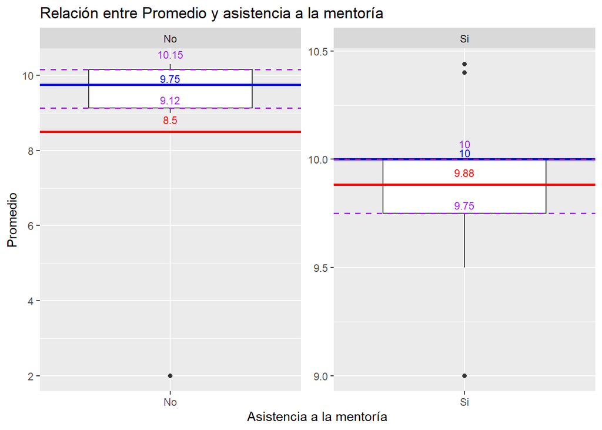

```r
data <- data.frame(promedio = DF$promedio_calculo[DF$promedio_calculo != 0],
                   asistencia = factor(DF$mentoria[DF$promedio_calculo != 0]))

data <- na.omit(data)
#data <- data[!data %in% "no participo"]
mean_vals <- data %>%
  group_by(asistencia) %>%
  summarise(mean_val = mean(promedio),
            median_val = median(promedio),
            q1_val = quantile(promedio, 0.25),
            q3_val = quantile(promedio, 0.75),
            interquartile_range = q3_val - q1_val)  # Calcular el rango intercuartil

ggplot(data, aes(x = asistencia, y = promedio)) +
  geom_boxplot() +
  geom_hline(data = mean_vals, aes(yintercept = mean_val), color = "red", linetype = "solid", size = 1) +
  geom_hline(data = mean_vals, aes(yintercept = median_val), color = "blue", linetype = "solid", size = 1) +
  geom_hline(data = mean_vals, aes(yintercept = q1_val), color = "purple", linetype = "dashed", size = 0.6) +
  geom_hline(data = mean_vals, aes(yintercept = q3_val), color = "purple", linetype = "dashed", size = 0.6) +
  geom_text(data = mean_vals, aes(x = asistencia, y = mean_val, label = round(mean_val, 2)), vjust = -1, color = "red", size = 3) +
  geom_text(data = mean_vals, aes(x = asistencia, y = median_val, label = round(median_val, 2)), vjust = -0.3, color = "blue", size = 3) +
  geom_text(data = mean_vals, aes(x = asistencia, y = q1_val, label = round(q1_val, 2)), vjust = -0.5, color = "purple", size = 3) +
  geom_text(data = mean_vals, aes(x = asistencia, y = q3_val, label = round(q3_val, 2)), vjust = -1.4, color = "purple", size = 3) +

  xlab("Asistencia a la mentoría") +
  ylab("Promedio") +
  ggtitle("Relación entre Promedio y asistencia a la mentoría") +
  facet_wrap(~asistencia, ncol = 2, scales = "free")  # Agregar facetas para separar los boxplots por asistencia
```

media -> 9.88 mediana -> 10 rango intercuartil -> 10 - 9.75 = 0.25

En este diagrama hay valores atípicos, por lo que tomamos a la mediana como medida de estudio y podemos observar tienen valores casi iguales, siendo 9.75 del grupo que no fueron a la mentoría y 10 de los que sí fueron a la mentoría. Hay una diferencia leve entre estos dos valores, por lo que para este caso tomaremos al valor del rango intercuartil. Este señala que en el Bloxpot1 los promedios del 50% de los estudiantes están mucho más dispersos que en el Bloxpot2. Asimismo, observamos que los datos atípicos del Bloxpot2 no se encuetran demasiado lejos del diagrama de cajas, mientras que en el Bloxpot 1 ocurre lo contrario. Esto puede ser un indicador de que las mentorías ayudaron a resolver las dudas de los estudiantes, pero no fueron suficientes para que todos comprendan los temas en su totalidad.

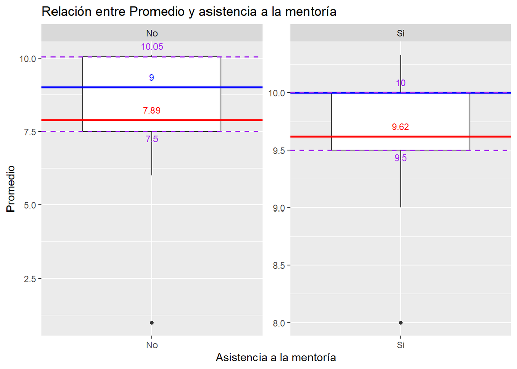

```r
library(tidyverse)

data <- data.frame(promedio = DF$promedio_quimica[DF$promedio_quimica != 0],
                   asistencia = factor(DF$mentoria[DF$promedio_quimica != 0]))

data <- na.omit(data)
#data <- data[!data %in% "no participo"]
mean_vals <- data %>%
  group_by(asistencia) %>%
  summarise(mean_val = mean(promedio),
            median_val = median(promedio),
            q1_val = quantile(promedio, 0.25),
            q3_val = quantile(promedio, 0.75),
            interquartile_range = q3_val - q1_val)  # Calcular el rango intercuartil

ggplot(data, aes(x = asistencia, y = promedio)) +
  geom_boxplot() +
  geom_hline(data = mean_vals, aes(yintercept = mean_val), color = "red", linetype = "solid", size = 1) +
  geom_hline(data = mean_vals, aes(yintercept = median_val), color = "blue", linetype = "solid", size = 1) +
  geom_hline(data = mean_vals, aes(yintercept = q1_val), color = "purple", linetype = "dashed", size = 0.6) +
  geom_hline(data = mean_vals, aes(yintercept = q3_val), color = "purple", linetype = "dashed", size = 0.6) +
  geom_text(data = mean_vals, aes(x = asistencia, y = mean_val, label = round(mean_val, 2)), vjust = -1, color = "red", size = 3) +
  geom_text(data = mean_vals, aes(x = asistencia, y = median_val, label = round(median_val, 2)), vjust = -1, color = "blue", size = 3) +
  geom_text(data = mean_vals, aes(x = asistencia, y = q1_val, label = round(q1_val, 2)), vjust = 1.5, color = "purple", size = 3) +
  geom_text(data = mean_vals, aes(x = asistencia, y = q3_val, label = round(q3_val, 2)), vjust = -1, color = "purple", size = 3) +

  xlab("Asistencia a la mentoría") +
  ylab("Promedio") +
  ggtitle("Relación entre Promedio y asistencia a la mentoría") +
  facet_wrap(~asistencia, ncol = 2, scales = "free")  # Agregar facetas para separar los boxplots por asistencia
```

media -> 7.89 mediana -> 9 rango intercuartil -> 10.05 - 7.5 = 2.55

media -> 9.62 mediana -> 10 rango intercuartil -> 10 - 9.5 = 0.5

Las mentorias ayudan a los estudiantes a mejorar sus calificaciones, principalmente en el curso de **Programación I**. Por lo que, si aumentamos el número de mentores ayudaría a aumentar la cantidad de estudiantes que logren aprobar o por lo menos subir sus promedios. Sin embargo, si se llega a aumentar la cantidad de mentores, estos tienen que tener la facilidad de poder explicar muy bien a los estudiantes y poder resolver todas sus dudas, muchas veces los mentores no cumplen con sus horas establecidas dado que ellos son estudiantes y a veces no disponen de mucho tiempo.

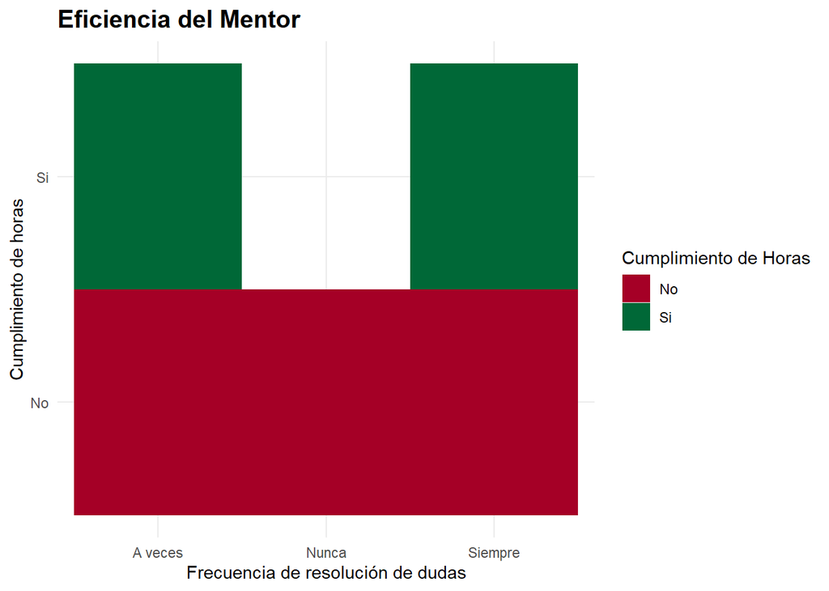

```r
DF_filtered <- DF %>%
  filter(!mentor_horas %in% "no participo", !mentor_dudas %in% "no participo")

ggplot(DF_filtered) +
  aes(x = mentor_horas, y = mentor_dudas, fill = mentor_horas) +
  geom_tile() +
  scale_fill_manual(
    values = c(No = "#A50026",
               Si = "#006837")
  ) +
  labs(
    x = "Cumplimiento de horas",
    y = "Frecuencia de resolución de dudas",
    title = "Eficiencia del Mentor",
    fill = "Cumplimiento de Horas"
  ) +
  coord_flip() +
  theme_minimal() +
  theme(plot.title = element_text(size = 15L, face = "bold"))
```

Podemos afirmar que se necesitan más mentores porque existen cupos limitados para las clases de mentorias, tomando en cuenta que dichos mentores tienen que ser responsable con sus horas de enseñanza.

## OBJETIVO 4

### Comparar los promedios de horas dedicadas de estudio de los estudiantes que reprobaron algún curso.

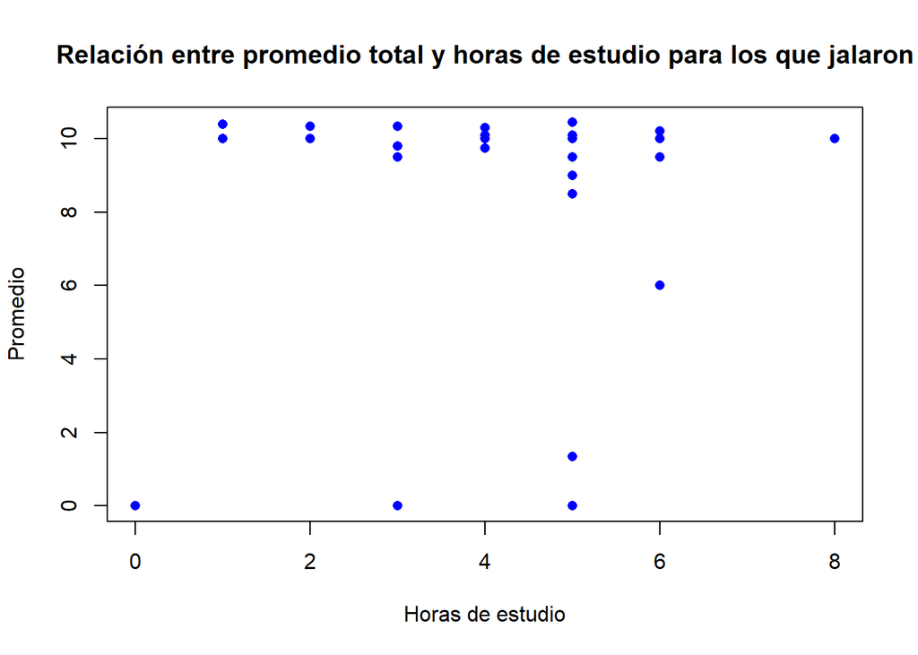

```r
# cursos jalados
filter_total_aprove <- DF[complete.cases(DF$promediototal, DF$horas_jalados), ] # horas de estudio que le dedican a los cursos que jalaron
# horas de estudio que ke dedican a los cursos que aprobaron

plot(filter_total_aprove$horas_jalados, filter_total_aprove$promediototal,
     xlab = "Horas de estudio", ylab = "Promedio",
     main = "Relación entre promedio total y horas de estudio para los que jalaron",
     col = "blue", pch = 16)
```

Cada punto en el gráfico representa un estudiante y su posición indica la cantidad de horas de estudio y su promedio. La mayor cantidad de estudiantes desaprobados dedicaban de 3 a 6 horas de estudio, posiblemente porque al tratar de dedicar muchas horas de estudios a sus cursos no logran cumplir con las horas respectivas para cada uno.

No se pueden sacar descriptores numéricos relevantes dado que no hay un relación clara entre estas dos variables. No existe mucha relación entre estas dos variable porque el promedio no siempre depende de las horas dedicadas a cada curso. Algunos “no estudian bien”; es decir, a pesar de dedicarle muchas horas de estudio a un curso al final no tiene impacto en sus promedios.

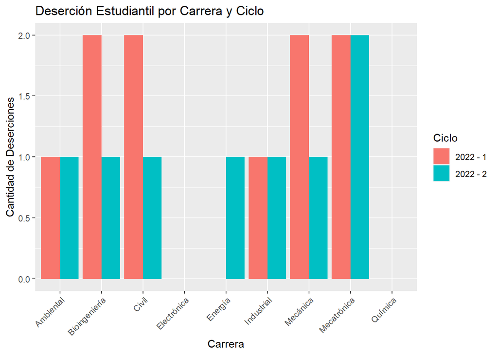

```r
# Crear un data frame con las variables relevantes
data <- data.frame(Carrera = DF$Carrera, Ciclo = DF$Ciclo, Desercion = DF$Veces_desaprobado)

# Filtrar los valores NA en la variable Desercion
data <- data[!is.na(data$Desercion), ]
#data <- data[!data %in% "no participo"]

# Generar el gráfico de barras agrupadas
ggplot(data, aes(x = Carrera, y = Desercion, fill = Ciclo)) +
  geom_bar(stat = "identity", position = "dodge") +
  xlab("Carrera") +
  ylab("Cantidad de Deserciones") +
  ggtitle("Deserción Estudiantil por Carrera y Ciclo") +
  theme(axis.text.x = element_text(angle = 45, hjust = 1))
```

## OBJETIVO 5

### Identificar el nivel de aprendizaje y dedicación de los alumnos en el curso.

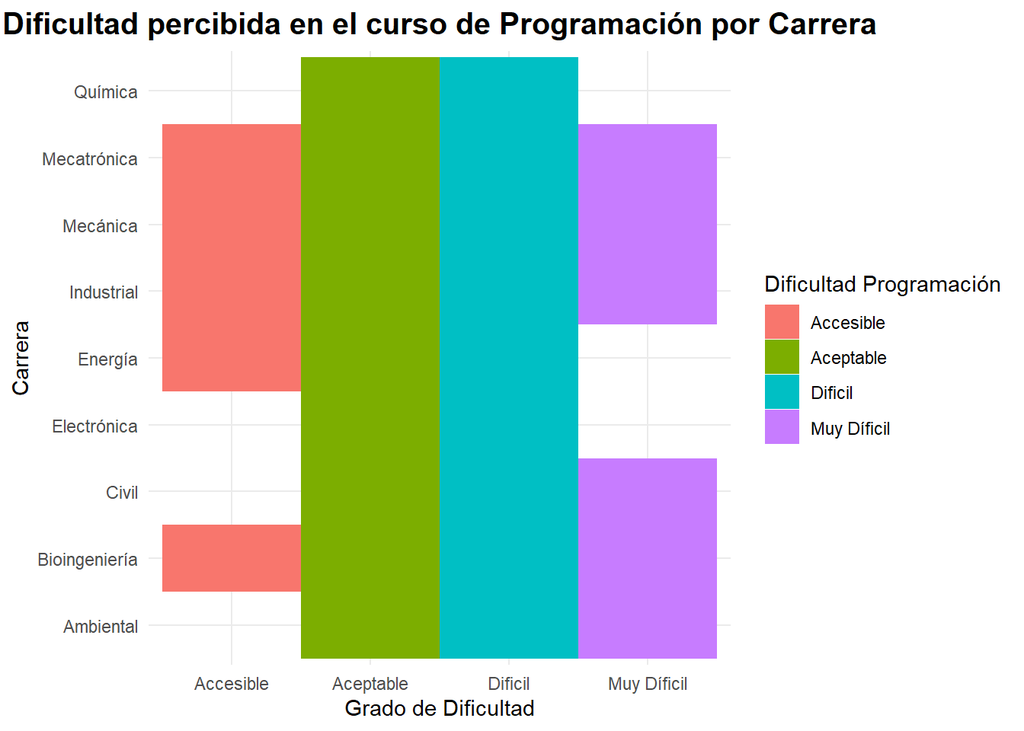

```r
# gráfico mosaico
ggplot(DF) +
 aes(x = Dificultad_progra, y = Carrera, fill = Dificultad_progra) +
 geom_tile() +
 scale_fill_hue(direction = 1) +
 labs(x = "Grado de Dificultad", y = "Carrera", title = "Dificultad percibida en el curso de Programación por Carrera",
 fill = "Dificultad Programación") +
 theme_minimal() +
 theme(plot.title = element_text(size = 15L,
 face = "bold", hjust = 0.5))
```

Los estudiantes de Ingeniería Ambiental, Civil, Mecánica, Mecatrónica, Industrial y Bioingeniría perciben como “muy difícil” el curso de Programación. Mientras el resto las percibe como “difícil”.

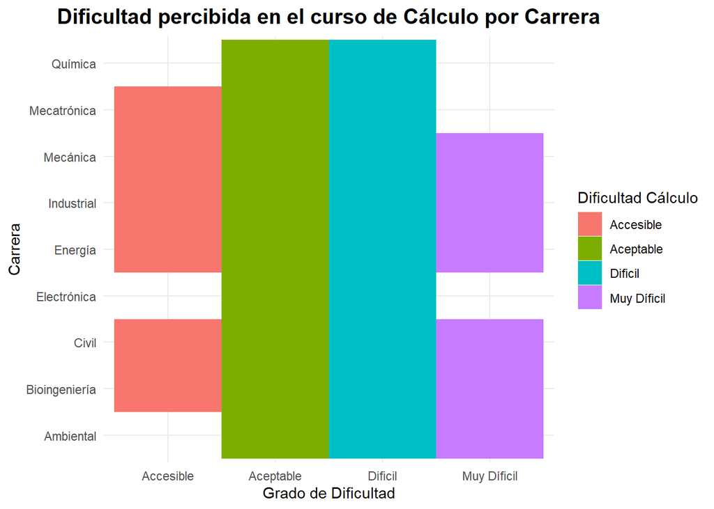

```r
ggplot(DF) +
 aes(x = Dificultad_calculo, y = Carrera, fill = Dificultad_calculo) +
 geom_tile() +
 scale_fill_hue(direction = 1) +
 labs(x = "Grado de Dificultad", y = "Carrera", title = "Dificultad percibida en el curso de Cálculo por Carrera",
 fill = "Dificultad Cálculo") +
 theme_minimal() +
 theme(plot.title = element_text(size = 15L,
 face = "bold", hjust = 0.5))
```

Algunos estudiantes de la carrera de Ingeniería Ambiental, Civil e Industrial, perciben como “difícil” el curso de Cálculo; mientras; Bioingeniería, Mecatrónica y de Energía perciben como “aceptable”.

Los estudiantes a pesar de que le dedicaban muchas horas de estudio a sus cursos estos desaprobaban, y una posible razón sería que no comprenden los temas.

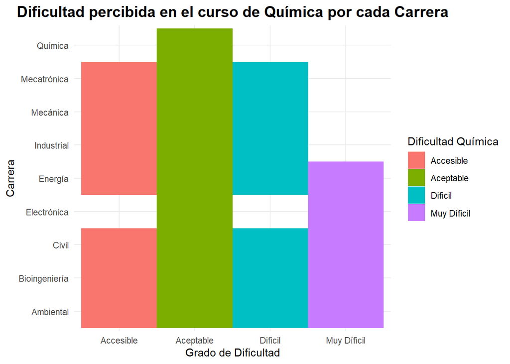

```r
ggplot(DF) +
 aes(x = Dificultad_quimica, y = Carrera, fill = Dificultad_quimica) +
 geom_tile() +
 scale_fill_hue(direction = 1) +
 labs(x = "Grado de Dificultad", y = "Carrera", title = "Dificultad percibida en el curso de Química por cada Carrera",
 fill = "Dificultad Química") +
 theme_minimal() +
 theme(plot.title = element_text(size = 15L,
 face = "bold", hjust = 0.5))
```

Existen diferencias significativas en la forma en que los estudiantes de cada carrera perciben la dificultad del curso de Química, puesto que las 5 carreras de las 9 que hay, consideran al curso como “muy difícil”.

Finalmente podemos decir que el promedio de un estudiante no solamente se dicta de acuerdo a las horas que le puede dedicar a ciertos cursos, sino también depende de las oportunidades que pueda aprovechar, tales como las mentorias o la nivelación. Asimismo, identificamos en que carrera hay mayor tasa de abandono, al saber de antemano los cursos y carreras donde hay más abandono podemos plantear e implementar soluciones eficaces, como: el aumento de mentores, más material de estudio o brindando clases para dar técnicas a los estudiantes con mayores dificultades para aprobar.

# **Análisis Probabilístico**

## **Probabilidad Empírica**

###**Probabilidad de como perciben los alumnos el nivel de dificultad de cada curso**

La variable “Nivel de dificultad” es importante dentro de este análisis dado que nos permite saber la probabilidad de que un estudiante percibe un curso como muy difícil o difícil, y gracias a ello podemos confirmar: “El curso de Cálculo de una variable es el curso más difícil, por lo que tiene una alta tasa de deserción”

PROGRAMACION

```r
nrow(subset(DF, Dificultad_progra == "Accesible")) / length(DF$Dificultad_progra)
```

```
## [1] 0.06
```

```r
nrow(subset(DF, Dificultad_progra == "Aceptable")) / length(DF$Dificultad_progra)
```

```
## [1] 0.3866667
```

```r
nrow(subset(DF, Dificultad_progra == "Dificil")) / length(DF$Dificultad_progra)
```

```
## [1] 0.4466667
```

```r
nrow(subset(DF, Dificultad_progra == "Muy Díficil")) / length(DF$Dificultad_progra)
```

```
## [1] 0.1066667
```

CALCULO

```r
nrow(subset(DF, Dificultad_calculo == "Accesible")) / length(DF$Dificultad_calculo)
```

```
## [1] 0.08
```

```r
nrow(subset(DF, Dificultad_calculo == "Aceptable")) / length(DF$Dificultad_calculo)
```

```
## [1] 0.3133333
```

```r
nrow(subset(DF, Dificultad_calculo == "Dificil")) / length(DF$Dificultad_calculo)
```

```
## [1] 0.46
```

```r
nrow(subset(DF, Dificultad_calculo == "Muy Díficil")) / length(DF$Dificultad_calculo)
```

```
## [1] 0.1466667
```

QUIMICA

```r
nrow(subset(DF, Dificultad_quimica == "Accesible")) / length(DF$Dificultad_quimica)
```

```
## [1] 0.1533333
```

```r
nrow(subset(DF, Dificultad_quimica == "Aceptable")) / length(DF$Dificultad_quimica)
```

```
## [1] 0.5133333
```

```r
nrow(subset(DF, Dificultad_quimica == "Dificil")) / length(DF$Dificultad_quimica)
```

```
## [1] 0.2866667
```

```r
nrow(subset(DF, Dificultad_quimica == "Muy Díficil")) / length(DF$Dificultad_quimica)
```

```
## [1] 0.04666667
```

##**Probabilidad de no jalar un curso**

```r
nrow(subset(DF, Veces_desaprobado == "0")) / length(DF$Veces_desaprobado)
```

```
## [1] 0.82
```

##**Probabilidad de jalar un curso**

```r
nrow(subset(DF, Veces_desaprobado == "1")) / length(DF$Veces_desaprobado)
```

```
## [1] 0.1466667
```

En conclusión, es muy probable que un alumno apruebe todos sus cursos en su primer ciclo.

##**Probabilidad de que un alumno no se retire de un curso**

```r
nrow(subset(DF, Veces_retirado == "0")) / length(DF$Veces_retirado)
```

```
## [1] 0.96
```

##**Probabilidad de que un alumno se retire de un curso**

```r
nrow(subset(DF, Veces_retirado == "1")) / length(DF$Veces_retirado)
```

```
## [1] 0.02666667
```

Es muy probable que un alumno no se retire de ningún curso en su primer ciclo.

## **Probabilidad Condicional**

Para todas las probabilidades a desarrollarse a continuación se seguirá la lógica explica a continuación, se tomará como ejemplo el caso de : Probabilidad de que un alumno que asistió a la mentoría haya aprobado.

si la probabilidad de que ocurra un evento A es la misma, sin importar si el evento B ocurre o no, entonces los eventos A y B son independientes. Esto significa que la ocurrencia o no ocurrencia de B no tiene influencia en la probabilidad de que ocurra A, y viceversa. Esto se traduce en la igualdad:

$P(A|B) = P(A)$

Si esta igualdad se cumple, entonces podemos decir que los eventos A y B son independientes. Si no se cumple, entonces los eventos son dependientes.Para verificar si estos eventos son independientes, calcularemos la probabilidad condicional de A dado B $(P(A|B))$ y la probabilidad de A $P(A)$, y luego compararlas.

En el contexto del estudio, podríamos definir los siguientes eventos:

##**Probabilidad de que un alumno que asistió a mentoria haya aprobado** $A$: Un estudiante haya aprobado . $B$: Un estudiante que asistió a mentoría .

```r
probabilidad <- sum(DF$mentoria == "Si" & DF$Veces_desaprobado == 0) / sum(DF$mentoria == "Si")
probabilidad
```

```
## [1] 0.8446602
```

##**Probabilidad de que un alumno que asistió a mentoría haya desaprobado**

```r
probabilidad <- sum(DF$mentoria == "Si" & DF$Veces_desaprobado > 0) / sum(DF$mentoria == "Si")
probabilidad
```

```
## [1] 0.1553398
```

Es muy probable que un alumno que asistió a mentoría haya aprobado.

##**Probabilidad de que un alumno que asistió a la nivelación haya aprobado**

```r
probabilidad <- sum(DF$Nivelacion == "Si" & DF$Veces_desaprobado == 0) / sum(DF$Nivelacion == "Si")
probabilidad
```

```
## [1] 0.8681319
```

##**Probabilidad de que un alumno que asistió a la nivelación haya desaprobado**

```r
probabilidad <- sum(DF$Nivelacion == "Si" & DF$Veces_desaprobado > 0) / sum(DF$Nivelacion == "Si")
probabilidad
```

```
## [1] 0.1318681
```

En conclusión, es muy probable de que un un alumno que asistió a nivelación haya aprobado.

##**Probabilidad de percepcion de dificultad del curso de Calculo, Programación y Quimica en alumnos cachimbos del año 2022.**

CALCULO

```r
sum( DF$Dificultad_calculo == "Accesible")/length(DF$Ciclo)
```

```
## [1] 0.08
```

```r
sum(DF$Dificultad_calculo == "Aceptable")/length(DF$Ciclo)
```

```
## [1] 0.3133333
```

```r
sum( DF$Dificultad_calculo == "Dificil")/length(DF$Ciclo)
```

```
## [1] 0.46
```

```r
sum(DF$Dificultad_calculo == "Muy Díficil")/length(DF$Ciclo)
```

```
## [1] 0.1466667
```

PROGRAMACION

```r
sum( DF$Dificultad_progra == "Accesible")/length(DF$Ciclo)
```

```
## [1] 0.06
```

```r
sum(DF$Dificultad_progra == "Aceptable")/length(DF$Ciclo)
```

```
## [1] 0.3866667
```

```r
sum( DF$Dificultad_progra == "Dificil")/length(DF$Ciclo)
```

```
## [1] 0.4466667
```

```r
sum(DF$Dificultad_progra == "Muy Díficil")/length(DF$Ciclo)
```

```
## [1] 0.1066667
```

QUIMICA

```r
sum( DF$Dificultad_quimica == "Accesible")/length(DF$Ciclo)
```

```
## [1] 0.1533333
```

```r
sum(DF$Dificultad_quimica == "Aceptable")/length(DF$Ciclo)
```

```
## [1] 0.5133333
```

```r
sum( DF$Dificultad_quimica == "Dificil")/length(DF$Ciclo)
```

```
## [1] 0.2866667
```

```r
sum(DF$Dificultad_quimica == "Muy Díficil")/length(DF$Ciclo)
```

```
## [1] 0.04666667
```

En conclusión, los cachimbos del año 2022 concuerdan que Calculo y Programacion son los cursos “más dificiles”.

##**Formula para identificar independiencia o dependecia**

```r
DF$mentoria <- DF$mentoria == "Si"  # Si los valores son "Asistió" y "No asistió"
```

```r
DF$promedio_calculo <- as.numeric(DF$promedio_calculo)
```

### Cálculo de la probabilidad condicional

```r
prob_condicional <- function(mentoria, promedio_calculo, DF) {
  prob_A <- sum(DF$mentoria, na.rm = TRUE) / sum(!is.na(DF$mentoria))  # Probabilidad marginal de A
  prob_AyB <- sum(DF$mentoria & DF$promedio_calculo, na.rm = TRUE) / sum(!is.na(DF$mentoria & DF$promedio_calculo))  # Probabilidad conjunta de A y B
  prob_B <- sum(DF$promedio_calculo, na.rm = TRUE) / sum(!is.na(DF$promedio_calculo))  # Probabilidad marginal de B

  prob_condicional <- prob_AyB / prob_B  # Cálculo de la probabilidad condicional

  return(prob_condicional)
}
```

### Verificación de dependencia o independencia

```r
verificar_dependencia <- function(mentoria, promedio_calculo, DF) {
  prob_condicional_empirica <- prob_condicional(mentoria, promedio_calculo, DF)

  # Calculando las probabilidades empíricas de A y B
  prob_A_empirica <- sum(DF$mentoria, na.rm = TRUE) / sum(!is.na(DF$mentoria))
  prob_B_empirica <- sum(DF$promedio_calculo, na.rm = TRUE) / sum(!is.na(DF$promedio_calculo))

  if (abs(prob_condicional_empirica - prob_A_empirica) < 0.0001) {
    cat("Los eventos", deparse(substitute(mentoria)), "y", deparse(substitute(promedio_calculo)), "son independientes.\n")
  } else {
    cat("Los eventos", deparse(substitute(mentoria)), "y", deparse(substitute(promedio_calculo)), "son dependientes.\n")
  }
}
```

```r
verificar_dependencia(DF$Nivelacion, DF$Veces_desaprobado, DF)
```

```
## Los eventos DF$Nivelacion y DF$Veces_desaprobado son dependientes.
```

```r
verificar_dependencia(DF$mentoria, DF$Veces_desaprobado, DF)
```

```
## Los eventos DF$mentoria y DF$Veces_desaprobado son dependientes.
```

## **Variables discretas**

### Distribución Binomial

X => número de personas que resolvieron todas sus dudas en la mentoria

Densidad

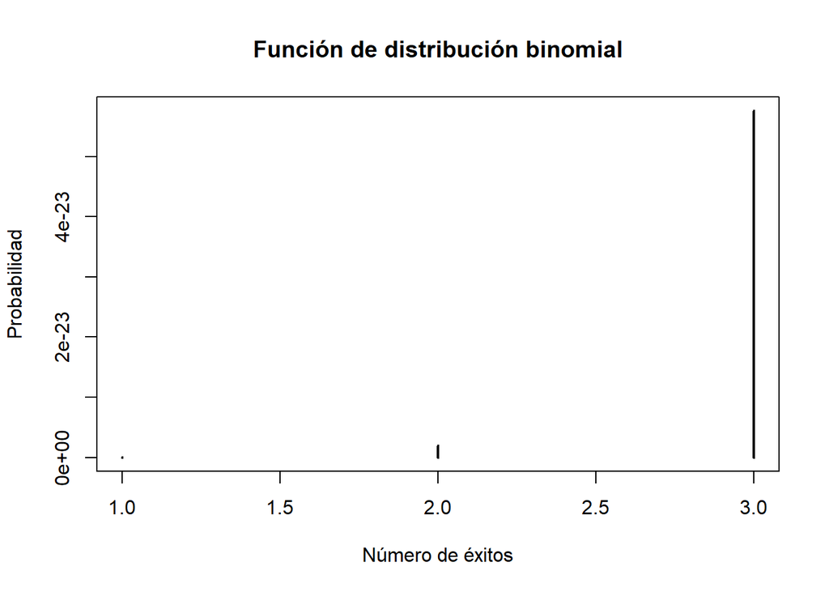

```r
variable <- DF$mentor_dudas
# Calcular los parámetros de la distribución binomial a partir de los datos
n <- 103 # Número de ensayos

# Calcular la función de distribución binomial
x <- 1:3  # Valores posibles del resultado
prob <- dbinom(x, n, 0.4563107)  # Probabilidad de cada resultado

# Graficar la función de distribución binomial
plot(prob, type = "h", lwd = 2, main = "Función de distribución binomial",
     xlab = "Número de éxitos", ylab = "Probabilidad")
```

Propiedades

```r
mean(DF$mentor_dudanum)
```

```
## [1] 1.68
```

```r
var(DF$mentor_dudanum)
```

```
## [1] 1.480805
```

```r
sd(DF$mentor_dudanum)/mean(DF$mentor_dudanum)*100
```

```
## [1] 72.43354
```

Ejemplo:

```r
pbinom(75,150,0.4563107)
```

```
## [1] 0.8760895
```

### Distribución hipergeométrica

X=>número de estudiantes que consideran “muy dificil” programación

X ~ Hiper(N=150, n=16, k=30))==> n =numero de personas que marcaron 4

Densidad

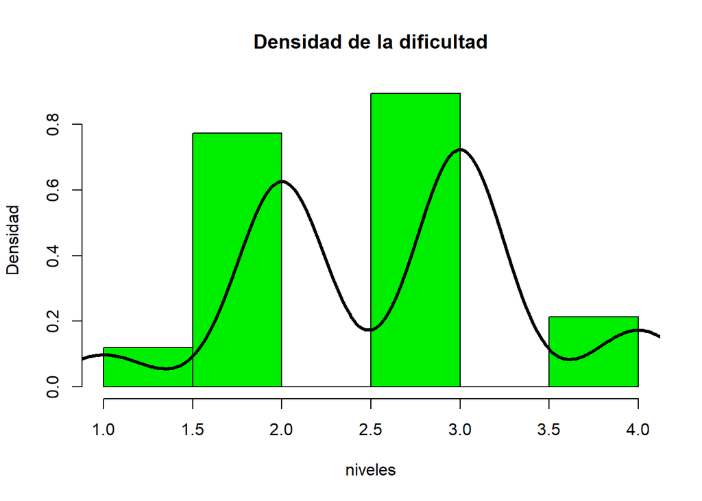

```r
hist(DF$dificultad_general, freq = FALSE, main = "Densidad de la dificultad",
     ylab = "Densidad",
     xlab = "niveles",
     col = "green2")

dx <- density(DF$dificultad_general)

lines(dx, lwd = 3, col = "black")
```

Propiedades

```r
mean(DF$dificultad_general)
```

```
## [1] 2.6
```

```r
var(DF$dificultad_general)
```

```
## [1] 0.5771812
```

```r
sd(DF$dificultad_general)/mean(DF$dificultad_general)*100
```

```
## [1] 29.22017
```

Ejemplo:

Se han encuestado a 150 estudiantes de UTEC ingresantes en el año 2022 y se les preguntó acerca del curso de programación. Se les preguntó acerca del nivel de complejidad y ellos seleccionaron un número en la escala del 1 al 4 en donde 1 significa “Accesible” y el 4 significa “Muy Dificil”. Del total de encuestados 9 estudiantes consideran “Accesible” el curso, 58 estudiantes marcaron “Aceptable”, 67 estudiantes marcaron “Dificil”, 16 estudiantes marcaron “Muy Dificil”. Si se va a escoger a 30 estudiantes al azar ¿Cuántos estudiantes que seleccionaron el nivel 4 estarían presentes en el grupo?

```r
round(30*16/150,0)
```

```
## [1] 3
```

## **Variables continuas**

### Distribución normal

Se identifica graficamente una normalidad

```r
XNOR_aprobados <- (DF$horas_aprobados +DF$horas_jalados)
mu <- mean(XNOR_aprobados)
sigma <- (var(XNOR_aprobados)^(1/2))
c(mu, sigma)
```

```
## [1] 6.470000 2.650965
```

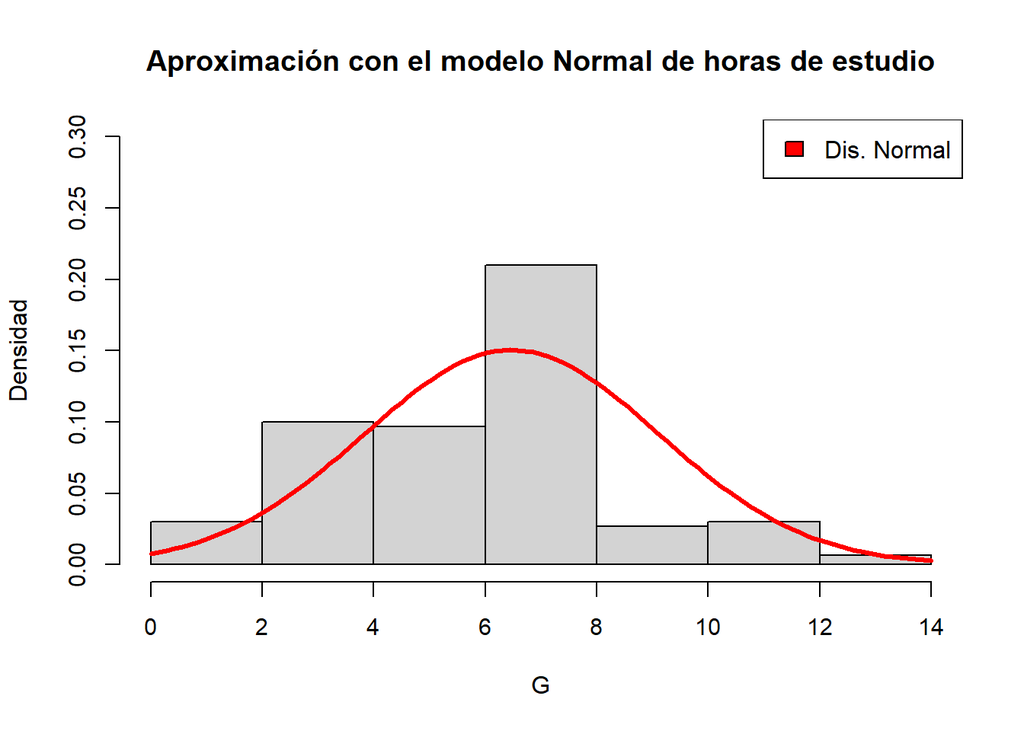

```r
hist(XNOR_aprobados
     , breaks = 6
     , probability =TRUE
     , ylim=c(0, 0.30)
     , xlab = "G"
     , ylab = "Densidad"
     , main = "Aproximación con el modelo Normal de horas de estudio"
     , cex.axis = 0.95
     )

curve(dnorm(x, mu, sigma), add = TRUE,col=c("red"),lwd=3)
legend("topright",legend = c("Dis. Normal"),fill = c("red"))
```

Se valida la normal con la media=mediana, varianza=sd2 y la esperenza=media

```r
print('media: ')
```

```
## [1] "media: "
```

```r
mean(XNOR_aprobados)
```

```
## [1] 6.47
```

```r
print('mediana:')
```

```
## [1] "mediana:"
```

```r
median(XNOR_aprobados)
```

```
## [1] 7
```

```r
print('varianza:')
```

```
## [1] "varianza:"
```

```r
var(XNOR_aprobados)
```

```
## [1] 7.027617
```

```r
print('desviacion: ')
```

```
## [1] "desviacion: "
```

```r
sd(XNOR_aprobados)**2
```

```
## [1] 7.027617
```

```r
print('esperanza:')
```

```
## [1] "esperanza:"
```

```r
mean(XNOR_aprobados)
```

```
## [1] 6.47
```

u=mean, g=sd => X ~ N(u, g)

X= horas de estudio dedicadas mayor a 7 horas

Ejemplo:

Se desea saber la cantidad de horas que utilizarían los alumnos para estudiar fuera de la universidad, se supone el caso para los alumnos más estudiosos los cuales deberían usar más horas. ¿Cual es la probabilidad de que un alumno del año 2022 haya utilizado más de 7 horas para estudiar?

```r
pnorm(q= 7, mean = 6.47, sd =2.650965, lower.tail = FALSE)
```

```
## [1] 0.4207688
```

### Distribución normal

Se identifica graficamente una normalidad

```r
XNOR_asesorias <- (DF$asesorias_proga +DF$asesorias_calculo + DF$asesorias_quimica)
mu <- mean(XNOR_asesorias)
sigma <- (var(XNOR_asesorias)^(1/2))
c(mu, sigma)
```

```
## [1] 12.200000  8.273026
```

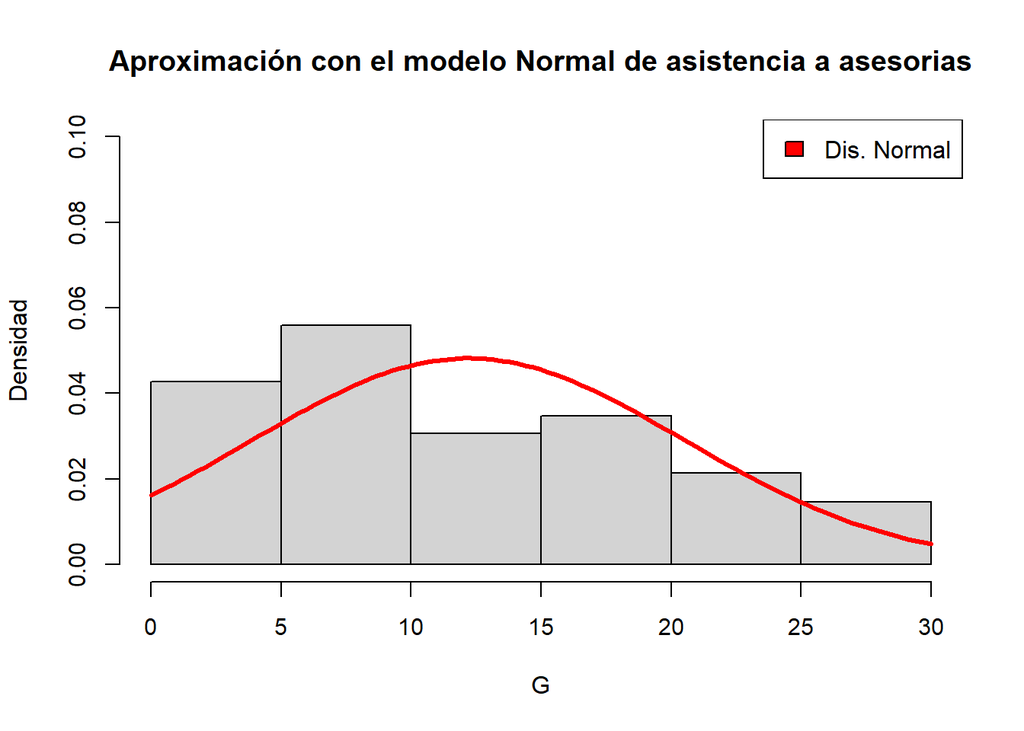

```r
hist(XNOR_asesorias
     , breaks = 10
     , probability =TRUE
     , ylim=c(0, 0.1)
     , xlab = "G"
     , ylab = "Densidad"
     , main = "Aproximación con el modelo Normal de asistencia a asesorias"
     , cex.axis = 0.95
     )

curve(dnorm(x, mu, sigma), add = TRUE,col=c("red"),lwd=3)
legend("topright",legend = c("Dis. Normal"),fill = c("red"))
```

Se valida la normal con la media=mediana, varianza=sd2 y la esperenza=media

```r
print('media: ')
```

```
## [1] "media: "
```

```r
mean(XNOR_asesorias)
```

```
## [1] 12.2
```

```r
print('mediana:')
```

```
## [1] "mediana:"
```

```r
median(XNOR_asesorias)
```

```
## [1] 12
```

```r
print('varianza:')
```

```
## [1] "varianza:"
```

```r
var(XNOR_asesorias)
```

```
## [1] 68.44295
```

```r
print('desviacion: ')
```

```
## [1] "desviacion: "
```

```r
sd(XNOR_asesorias)**2
```

```
## [1] 68.44295
```

```r
print('esperanza:')
```

```
## [1] "esperanza:"
```

```r
mean(XNOR_asesorias)
```

```
## [1] 12.2
```

u=mean, g=sd => X ~ N(u, g)

X = numero de personas que asistieron a menos de 11 asesorias

Ejemplo:

```r
pnorm(q= 10, mean = 12.2, sd =8.273026 , lower.tail = TRUE)
```

```
## [1] 0.3951487
```

# **Conclusiones**

Objetivo General

Se identifican que las causas de causas que llevan a un estudiante de primer ciclo a reprobar y/o retirarse de un curso general son: - Falta de técnicas de estudio - Falta de una base teórica y práctica para cursos generales, especialmente en Cálculo y Programación I - Los mentores no logran resolver una gran parte de dudas de los alumnos por falta de horas extra de mentorias

Objetivos especificos